# documentation

## 1 - Overview

https://github.com/Lars314/gm2-artificial-islands

The motivation of this project was to have a way to create artificial pileup islands for training and testing a machine learning model to indentify the number of pulses in an island. A custom artificial island generator was chosen instead of using existing real data in order to have control over the islands for dataset construction and testing, and to easily create edge cases or datasets which are unrealistic, but improve the robustness of the model. For example, teaching the model using *only* a realistic distribution of pileup in the experiment would not work. The number of single pulses is much greater than for doubles, which is much greater than for triples. A model trained with that distribution would likely identify every event as a single. Artificial island generation allows for exact control of how many singles/doubles/triples we have in a dataset, or the time separation between pulses, the energies, the noise, etc. Although it would be possible to apply cuts on each of these to real data, and artificially add noise to that, this method lets us generate as many such events as we want independantly from the fitter already being used in the experiment.

The main file, `artificialIslands.py` is broken into five classes: Island, Calo, Xtal, Template, and Particle. The island class is what the user interacts with the most. Upon initialization, an island object will create one calo object, with 54 xtal objects. The island will decide on a number of particles based on a configuration file, and create that many particle objects. Each of these has data sent to the calo object, 'impacting the calorimeter.' The calo object then calculates which crystals recieved energy, and those crystals build their ADC amplitude vs time traces with that energy information. The trace shape comes from a Template object, which converts a spline crystal fitting template from a root file to a python format. After all of the hit crystals in a calorimeter have had their traces built, the calorimeter performs chopping based on values in the configuration file. The chopped traces are then given to the island object, which formats them into an output dictionary along with the number of impacts. Those data formed the respective x and y data for the machine learning model.

This project was made stand-alone from the machine learning project in case there is anyone who has use for something similar. This notebook documents the parameters, attributes, and methods in the file.

### 1.1 - fclParse

fclParse was written by Joshua LaBounty to read a fcl file into a dictionary. It is used here to read in noise levels and energy calibration values for the different crystals. These files are specified in the configuration file.

## 2 - Limitations

There are many limitations to this island generator, particularly because the original focus was on flexibility rather than strict realism. Many approximations were made, and some features are currently still missing. This project's goal was to make something that looks enough like an island for the number of particle hits to be identified, and so the nuance in things such as energy values was left out.

### 2.1 - Position and Energy Distribution

Currently, the program generates particles with independant energy and impact position. The energy and position distrubutions are also inaccurate, any x or y are equally likely, and any energies in a range specified in the configuration file are equally likely. This is not accurate, and this version does not contain a fix.

### 2.2 - Crystal Energy Calculation

The process of deciding what energy gets deposited in each crystal is unrealistic. It produces good enough island shapes, but currently the specific values of energy are a major limitation. Because the original motivation was creating a model for identifying the number of pulses in an island, the energy of those pulses were secondary to the positioning of the pulses.

### 2.3 - Normalization

Currently, crystal traces can only be normalized individually, without the broader context of the entire island. When this kind of normalization is applied, because each trace template is almost the same, each crystal trace gets almost the same height. The exeption is when there are multiple pulses in a single trace. Then the integral of that trace is higher without necessarily increasing the trace amplitude compared to a single pulse of the same energy, so traces with multiple pulses separated in time will have lower normalized amplitudes. This was implemented as a "what if" sort of question to try and make pileup with short spatial separation but long time separation easier for a machine learning model to identify.

### 2.4 - Calorimeter Number Effects

Currently, an island can be make with a specific calorimeter number in mind, but it does nothing. It is just a parameter of the island constructor and defaults to 1. Any kind of effect that would vary from one calo to another is not considered.

### 2.5 - Time-in-fill Effects

Time in fill is also not considered. Any early to late effects that might change the way an island is likely to look are not present here.

## 3 - Configuration

Parameters are set using a json configuration file `artificalIslands_config.json`. There are several parameters:

#### 3.1 - Particle Parameters

`minPulses` : int - The minimum number of pulses in the island

`maxPulses` : int - The maximum number of pulses in the island. If this is the same value as minPulses, that many pulses will be generated.

`deltaTmin` : float, ns - The minimum time value for where a pulse can be.

`deltaTmax` : float, ns - The maximum time value for where a pulse can be.

`minTimeOffset` : float, ns - The minimum time separation between any two pulses. Set as zero to disable.

`maxTimeOffset` : float, ns - The maximum time separation between any two pulses. Set as null to disable. Currently not implemented and will do nothing.

`eLow` : float, MeV - The minimum energy for each particle.

`eHigh` : float, MeV - The maximum energy for each particle.

#### 3.2 - Crystal Trace Parameters

`samplingRateArtificial` : float, nHz- The sampling rate of the trace. This is set to 1.25 by default to match the ADC.

`minFitEnergy` :float, MeV - The minimum energy in a crystal for its trace to be built. The fitter ignores anything under 50 MeV, so we may as well too.

#### 3.3 - Method Parameters

`normalize` : boolean - Normalize the crystal using the summed pulse integrals in the entire calo or not. Currently not implemented and will do nothing.

`normalizeXtal` : boolean - Normalize each crystal trace individually or not. Effectively removes energy information from the calorimeter, although traces with multiple pulses will be lower as they get divided by a larger integral in time.

`doChop` : boolean - Do crystal trace chopping or not. If true, each crystal trace will be cut to the same length, with nPreSamples before the time index of the first trace value above the chop threshold in the calorimeter, and nPostSamples after the last. The calo object will check every crystal's trace for the indices of the first and last time a value in each trace is greater than the threshold. It will then find the global first and last indices, and then subtract the number of pre-samples from the first, and add the number of post-samples to the last. The trace values within that range of indices is then saved to the island. If doChop is set to false, that process does not happen and the entire trace is saved to the island.

`chopThreshold` : float, ADC units - The trace amplitude that defines where chopping starts and ends.

`nPreSamples` : int - The number of samples/indices in front of the first value greater than chopThreshold that is saved in chopped traces.

`nPostSamples` : int - The number of samples/indices behind the last value greater than chopThreshold that is saved in chopped traces.

`noise` : boolean - Add noise to the island traces or not. Noise values are given in a fcl file noiseValueFcl (see template parameters below).

`randomizeTailLength` : boolean - true/false to give each trace a random tail length before chopping. Currently setting this to true produces errors.

`nTailSamples` : int - The number of tail samples before chopping if we are not randomizing the tail length.

`doPedestal` : boolean - Offset the trace by a pedesal value or not. If true, every trace value will get subtracted by a pedestal value.

`pedestal` : float, ADC units - The mean pedestal value. If doPedestal is true, each crystal will get a pedestal value centered at this plus or minus a few randomly determined ADC units.

`energyMethod` : string - So far can only be "linear." "linear" in this case means that energy values for each particle are selected randomly with every value between eLow and eHigh equally likely. This is not at all realistic, however. Other methods are not implemented yet, but a more realistic energy distribution is a current goal.

`positionMethod` : string - So far this can only be "random." "random" in this case means that x, y, and energy for each particle impacting the calorimeter are independant. The position has no energy dependance, and any location in x or y is equally likely. This is not at all realistic, however. As with energyMethod, other methods are not implemented yet, but making position distribution realistic, and having position realistically depend on energy are current goals.

#### 3.4 - Template Parameters

`energyCalibrationFcl` : string - The path to a fcl file containing energy calibration constants. An example one included in this repository is `mipEnergyCalibration_PostDisk_CoincidencNumber_2.fcl`.

`noiseValueFcl` : string - The path to a fcl file containing noise standard deviations for each crystal. An example one included in this repository is `gm2pedestals_run3formatRE.fcl`.

`templateFile` : string - The path to a ROOT file containing rSpline pulse templates. An example one included in this repository is `calotemplate15.root`.

`moliereRadius` : float, cm - The moliere radius in centimeters of the crystals.

#### 3.5 - Debug Parameters

`verbosity` : boolean - Print debugging statements or not. Quite a bit gets printed, so be sure to turn this off if you are generating multiple islands.

## 4 - Drawing

Drawing is handled via the `draw()` function. It accepts an island, and several parameters:

`draw(this_island, legend=False, show_moliere_radius=False, show_hit_xtals=False, show_xtal_energies=False, show_hit_label=False, show_traces=False, energy_cmap=False, ring_alpha=None, label_e_scale='G')`

`this_island` : Island - The island to be drawn.

`legend` : boolean - Show the legend or not. The legend contains particle number, energy, and impact time.

`show_moliere_radius` : boolean - Show the a circle with the moliere radius or not, to help visualize the impact. A second circle is drawn with twice the moliere radius as well.

`show_hit_xtals` : boolean - Change the background of impacted crystals to grey or not.

`show_xtal_energies` : boolean - Show the energy deposited for each crystal or not.

`show_hit_label` : boolean - Show a label near the particle impact location with the particle number or not.

`show_traces` : boolean - Plot built traces in their respective crystals or not.

`energy_cmap` : boolean - Use a cmap for coloring impacts based on energy or not. If false, colors will be taken from the standard matplotlib color scheme.

`ring_alpha` : float - Change the opacity of the moliere rings and impact marker.

`label_e_scale` : string - Choose what unit to use in the legend. "M" will give MeV. Anything else will give GeV.

#### Examples:

```python
import artificialIslands as aris
import matplotlib.pyplot as plt

this_island = aris.Island()
```

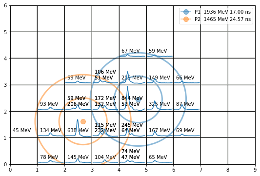

```python
aris.draw(this_island, legend=True, show_moliere_radius=True,
          show_hit_xtals=False, show_xtal_energies=True,
          show_hit_label=False, show_traces=True, energy_cmap=False,
          label_e_scale='M', ring_alpha=0.5)
```

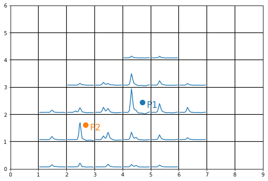

```python
aris.draw(this_island, legend=False, show_moliere_radius=False,
          show_hit_xtals=False, show_xtal_energies=False,
          show_hit_label=True, show_traces=True, energy_cmap=False,
          label_e_scale='M', ring_alpha=1)
```

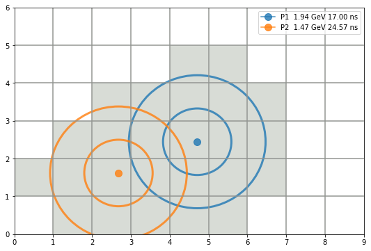

```python
aris.draw(this_island, legend=True, show_moliere_radius=True,
          show_hit_xtals=True, show_xtal_energies=False,
          show_hit_label=False, show_traces=False, energy_cmap=False,
          label_e_scale='G', ring_alpha=0.8)
```

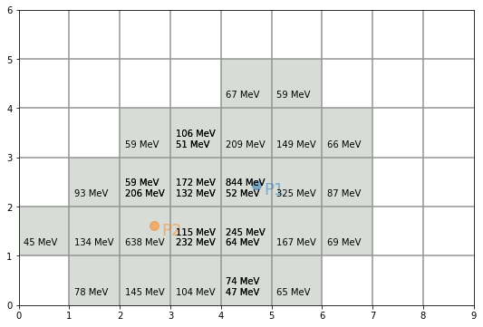

```python
aris.draw(this_island, legend=False, show_moliere_radius=False,
          show_hit_xtals=True, show_xtal_energies=True,
          show_hit_label=True, show_traces=False, energy_cmap=False,
          label_e_scale='M', ring_alpha=0.5)
```

## 5 - Classes

### 5.1 - Island Class

#### Attributes:

`nParticles` : int, the number of particles in this island

`particles` : list, a list of particle objects for this island

`timeOffsets` : list, the locations in time for each particle

`energies_list` : list, the energies of each particle in the same order as timeOffsets

`saved_traces` : numpy.ndarray, the traces of every crystal as a 3D array

`output`: dictionary, a dictionary containing the saved traces, energies, and number of particles

#### Methods:

`giveNPulses_(self, verbosity, minPulses, maxPulses)`

```
    figure out how many pulses there will be
    never run this outside of initialization
```

`giveTimeOffsets_(self, verbosity, deltaTmin, deltaTmax)`

```
    Creates the time offset values for each pulse.
    Make deltaTmax >> minTimeOffset, otherwise
    this will take absolutely forever to run
```

`__init__(self, caloNum=1)`

```
    caloNum:    [int] The calorimeter number of this island
```

### 5.2 - Calo Class

#### Attributes:

`caloNum` : int, the calorimeter number

`impacts` : list, a list of dictionaries where each dictionary is one particle impact with x, y, time, energy, hit crystal indices, and moliere ring coordinates which are used to find the hit crystals

`xtalGrid` : list, a 2D list of xtal objects representing the calo face

#### Methods:

`impact(self, p)`

```
    A positron hits. Save relevant information so we can send it to the
    hit crystals later
```

`clear(self)`

```
    Deletes all the impacts, clears the crystal grid
```

`chop(self)`

```
    Performs simulated island chopping. We don't want a bunch of zero
    values if we have many many data, so we cut islands
    down to just the interesting stuff. We keep preSamples before the
    first value over our threshold value, and postSamples after the
    last
```

`build(self)`

```
    after things have impacted, we build all the traces
```

`get_energy_density_(self, r)`

```
    The energy density of the impacted particle over the region of impact.
    This will change, 1/r is definitely not right but easy for testing
```

`get_crystal_energy_(self, xtal_loc, impact_loc, impact_energy)`

```
    For some crystal, hit location, and hit energy, we calculate how much
    energy was deposited into this crystal.

    Currently this method is inaccurate. We are assuming that the energy
    is distributed evenly accross the face of the crystal, with the energy
    density of the center of the crystal. Additional complications come
    from energy loss at the borders of crystals. These are ignored. We can
    do this for now because we are mostly interested in the number of
    impacts, not the specific energies.
```

`get_hit_crystals_(self)`

```
    Figure out which crystals are hit by which pulse
```

`build_impacted_crystals_(self)`

```
    Go through the xtalGrid, and build any non empty crystals' traces
```

`reset_xtalGrid_(self)`

```
    Creates a fresh grid of crystals. Use when initializing the calo, or
    when clearing it of impacts.
```

`__init__(self, caloNum)`

### 5.3 - Xtal Class

#### Attributes:

`caloNum` : int, the calorimeter number between 1 and 24

`x` : int, the x index of the crystal, between 0 and 8 inclusively

`y` : int, the y index of the crysal, between 0 and 5 inclusively

`impacts` : 2D list, each entry is a list representing a particle's energy deposition into this crystal as [time (ns), energy (MeV)]

`time` : list, a list of time values matching the order and shape of the trace attribute

`trace` : list, a list of amplitude values for the pulses, in the same order and shape of the time attribute

`integral` : float, the pulse integral

`noiseLevel` : float, the standard distribution of noise in ADC units for this crystal

`energyCalibrationVal` : float, the energy calibration value for this crystal to go between ADC units and energy

`template` : template, the pulse template for this crystal

`chopThreshold` : float, the same as chpThreshold in the configuration file, but saved here so that it can be scaled as needed for normalization or pedestal offsets if done

`choppedTrace` : list, a list of amplitude values for the pulses, but chopped around the pulses based on the configuration chopping parameters

#### Methods:

`energize(self, impact_time, xtal_energy)`

```
    Put energy into this crystal. The energy is calculated at the
    calorimeter level
```

`build_trace(self)`

```
    Finalizes the crystal, gets the trace set up. In version one this
    was done in the constructor, but we need to be able to add energy
    values to this crystal before building it.
```

`do_chop(self, startIndex, endIndex)`

```
    Performs chopping with the indices found at the calo level
```

`find_chop_indices(self)`

```
    goes through the trace and gives chop index recommendation based on
    this crystal and the config thresholds
```

`digitize_(self, verbosity, thisTrace, theseTimes)`

```
    convert the time sampling to match that of the ADC
    by default this should be 1.25ns sampling
```

`giveRandomTailLength_(self)`

```
    figure out how long the tail will be
    never run this outside of initialization
```

`convertToADC_(self, energy)`

```
    convert some energy to ADC units for this crystal
```

`giveNoise_(self, thisTrace)`

```
    adds gaussian noise into the island, in ADC units. Do not use this
    function unless you are operating in ADC units
```

`clear_(self)`

```
    Deletes information from this crystal
```

`addPedestal_(self, trace)`

```
    This just shifts all the trace by the pedestal
    value, to make the y axis scale a little more realistic. For
    right now, the pedestal value is just made randomly. As far as
    I know there is no fcl file with the pedestal values for each
    crystal, but if there are that would be better.
```

`integrate_(self, time, trace)`

```
    Returns the integral of the trace, the area under the curve
```

`__init__(self, caloNum=None, x=None, y=None, xtalNum=None)`

```
    caloNum : [int] the number of the calorimeter where this crystal lives

    x       : [int] the x position of this crystal, in crystal units

    y       : [int] the y position of this crystal, in crystal units

    eCalVal : [float] the energy calibration value for this crystal
```

### 5.4 - Template Class

#### Attributes:

`trace` : list, a list of values from the rSpline trace template organized according to the same shape and order as the time attribute

`time` : list, a list of time values

`samplingRate` : float, the time value sampling rate

`xtalNum` : int, the crystal number between 1 and 54

`caloNum` : int, the calorimeter number between 1 and 24

#### Methods:

`peakTime(self)`

`getPeak(self)`

`getNormalIntegral(self)`

`__init__(self, pySpline=None, rSpline=None, xtalNum=None, caloNum=None)`

### 5.5 - Particle Class

#### Attributes:

`energy` : float, the energy of this particle in MeV

`x` : float, the x position of the particle's impact on the calo face, in crystal units

`y` : float, the y position of the particle's impact on the calo face, in crystal units

`time` : float, the time of the particle's impact on the calo face, in ns. This is not time in fill, but a relative time for the trace.

#### Methods:

`giveEnergy_(self)`

```
    Calculates and assigns an impact total energy in MeV
```

`giveX_(self)`

```
    Caclulates and assigns an impact x position
```

`giveY_(self)`

```
    Calculates and assigns an impact y position
```

`__init__(self, time=None, x=None, y=None, energy=None)`

```
    x      : [float] the x position of the particle on the calo face,
             in calo crystal units

    y      : [float] the y position of the particle on the calo face,
             in calo crystal units

    energy : [float] the energy of this particle

    time   : [float] the time this particle hits the calorimeter
```

## 6 - Some Examples

```python
import artificialIslands as aris
import matplotlib.pyplot as plt

this_island = aris.Island()
```

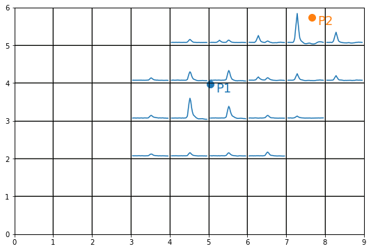

```python
aris.draw(this_island, legend=False, show_moliere_radius=False,
          show_hit_xtals=False, show_xtal_energies=False,
          show_hit_label=True, show_traces=True, energy_cmap=False,
          label_e_scale='M', ring_alpha=1)
```

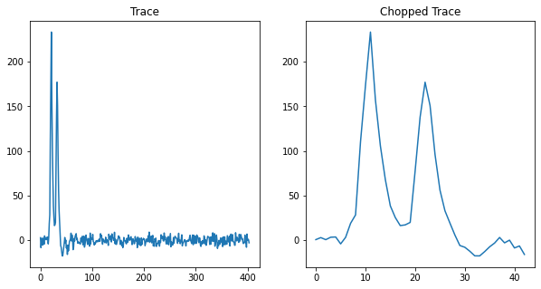

```python
fig, ax = plt.subplots(1, 2);
fig.set_size_inches(10, 5);

ax[0].plot(this_island.calo.xtalGrid[6][4].trace);
ax[1].plot(this_island.calo.xtalGrid[6][4].choppedTrace);

ax[0].set_title('Trace');
ax[1].set_title('Chopped Trace');
```

```python
print(this_island)
```

```
----- New Island -----
Number of Particle Hits : 2
Particle Energies : 1532 MeV    1970 MeV
```

```python
print(this_island.particles[0])
print(this_island.particles[1])
```

```
----- New Particle -----
(x, y) : (5.04, 3.96)
Energy : 1532.00 MeV
Time : 21.83 ns


----- New Particle -----
(x, y) : (7.66, 5.74)
Energy : 1970.00 MeV
Time : 7.51 ns
```

```python
print(this_island.calo)
```

```
Crystal 0 at (1, 1) has [time (ns), energy (MeV)]: []

Crystal 9 at (1, 2) has [time (ns), energy (MeV)]: []

Crystal 18 at (1, 3) has [time (ns), energy (MeV)]: []

Crystal 27 at (1, 4) has [time (ns), energy (MeV)]: []

Crystal 36 at (1, 5) has [time (ns), energy (MeV)]: []

Crystal 45 at (1, 6) has [time (ns), energy (MeV)]: []

Crystal 1 at (2, 1) has [time (ns), energy (MeV)]: []

Crystal 10 at (2, 2) has [time (ns), energy (MeV)]: []

Crystal 19 at (2, 3) has [time (ns), energy (MeV)]: []

Crystal 28 at (2, 4) has [time (ns), energy (MeV)]: []

Crystal 37 at (2, 5) has [time (ns), energy (MeV)]: []

Crystal 46 at (2, 6) has [time (ns), energy (MeV)]: []

Crystal 2 at (3, 1) has [time (ns), energy (MeV)]: []

Crystal 11 at (3, 2) has [time (ns), energy (MeV)]: []

Crystal 20 at (3, 3) has [time (ns), energy (MeV)]: []

Crystal 29 at (3, 4) has [time (ns), energy (MeV)]: []

Crystal 38 at (3, 5) has [time (ns), energy (MeV)]: []

Crystal 47 at (3, 6) has [time (ns), energy (MeV)]: []

Crystal 3 at (4, 1) has [time (ns), energy (MeV)]: []

Crystal 12 at (4, 2) has [time (ns), energy (MeV)]: []

```

[output cut: 52 more lines]

```
Crystal 43 at (8, 5) has [time (ns), energy (MeV)]: [[7.512468419228655, 166.9685762124853]]

Crystal 52 at (8, 6) has [time (ns), energy (MeV)]: [[7.512468419228655, 783.3492812728063]]

Crystal 8 at (9, 1) has [time (ns), energy (MeV)]: []

Crystal 17 at (9, 2) has [time (ns), energy (MeV)]: []

Crystal 26 at (9, 3) has [time (ns), energy (MeV)]: []

Crystal 35 at (9, 4) has [time (ns), energy (MeV)]: []

Crystal 44 at (9, 5) has [time (ns), energy (MeV)]: [[7.512468419228655, 122.37600802952797]]

Crystal 53 at (9, 6) has [time (ns), energy (MeV)]: [[7.512468419228655, 289.10463957983137]]
```